# 复现 Card & Krueger (1994)：最低工资与就业

Author

Yinkai Niu

Published

April 22, 2026

## 1. 引言

Card 和 Krueger（1994）是实证经济学中最具影响力的论文之一，发表于 *American Economic Review*。该研究挑战了传统经济学的核心预测：**提高最低工资会降低就业**。

### 研究背景

1992年4月1日，新泽西州（NJ）将最低工资从每小时 $4.25 提高到 $5.05。相邻的宾夕法尼亚州（PA）最低工资保持不变。作者在政策实施前（1992年2月）和实施后（1992年11月）调查了两个州共约410家快餐连锁店，比较就业变化。

### 因果识别策略：双重差分（Difference-in-Differences, DiD）

$$\text{DiD} = (\bar{Y}_{NJ,\text{after}} - \bar{Y}_{NJ,\text{before}}) - (\bar{Y}_{PA,\text{after}} - \bar{Y}_{PA,\text{before}})$$

这种方法的因果逻辑是：

- **宾夕法尼亚州**作为**对照组**，代表”如果没有政策，新泽西州会发生什么”
- 两组在政策前有**平行趋势**（parallel trends）的假设
- 通过差分消除了共同时间趋势的干扰（如宏观经济波动）
- 因此，DiD估计量可以被解读为最低工资政策对就业的**因果效应**

## 2. 数据读取与准备

```r
library(tidyverse)
library(knitr)
library(broom)

# 直接从 Card 的主页下载数据
temp <- tempfile()
download.file("http://davidcard.berkeley.edu/data_sets/njmin.zip",
              destfile = temp, mode = "wb")
tempdir_path <- tempdir()
unzip(temp, exdir = tempdir_path)

# 读取变量名（来自 codebook）
codebook <- read_lines(file.path(tempdir_path, "codebook"))

variable_names <- codebook[8:59] %>%
  `[`(-c(5, 6, 13, 14, 32, 33)) %>%
  str_sub(1, 13) %>%
  str_squish() %>%
  str_to_lower()

# 读取数据
df <- read_table(file.path(tempdir_path, "public.dat"),
                 col_names = FALSE) %>%
  select(-X47) %>%
  `colnames<-`(variable_names) %>%
  mutate_all(as.numeric)

# 构建关键变量
df <- df %>%
  mutate(
    nj         = state,
    fte_before = empft  + 0.5 * emppt  + nmgrs,
    fte_after  = empft2 + 0.5 * emppt2 + nmgrs2,
    fte_change = fte_after - fte_before,
    state_name = if_else(nj == 1, "New Jersey", "Pennsylvania")
  )

cat("数据读取成功！共", nrow(df), "家餐厅\n")
```

```
数据读取成功！共 410 家餐厅
```

## 3. 复现 Table 2：描述性统计

```r
chars <- df %>%
  group_by(state_name) %>%
  summarise(
    `FTE 就业（调查前）`  = round(mean(fte_before, na.rm = TRUE), 2),
    `全职员工比例`        = round(mean(empft / (empft + emppt), na.rm = TRUE), 3),
    `初始工资（$/hr）`    = round(mean(wage_st, na.rm = TRUE), 2),
    `营业时间（小时/天）` = round(mean(hrsopen, na.rm = TRUE), 2),
    `样本量 N`            = n()
  ) %>%
  pivot_longer(-state_name, names_to = "变量") %>%
  pivot_wider(names_from = state_name, values_from = value)

kable(chars,
      col.names = c("变量", "New Jersey", "Pennsylvania"),
      align     = c("l", "c", "c"),
      caption   = "Table 2 复现：调查前各餐厅特征均值")
```

Table 2 复现：调查前各餐厅特征均值

| 变量 | New Jersey | Pennsylvania |
| --- | --- | --- |
| FTE 就业（调查前） | 20.440 | 23.330 |
| 全职员工比例 | 0.286 | 0.303 |
| 初始工资（$/hr） | 4.610 | 4.630 |
| 营业时间（小时/天） | 14.420 | 14.530 |
| 样本量 N | 331.000 | 79.000 |

## 4. 复现 Table 3：双重差分核心结果

Table 3 是论文的核心，展示各连锁店就业变化的 DiD 估计。

```r
# 计算各组均值和标准误
stats <- df %>%
  group_by(state_name) %>%
  summarise(
    before_mean = mean(fte_before, na.rm = TRUE),
    before_se   = sd(fte_before,   na.rm = TRUE) / sqrt(sum(!is.na(fte_before))),
    after_mean  = mean(fte_after,  na.rm = TRUE),
    after_se    = sd(fte_after,    na.rm = TRUE) / sqrt(sum(!is.na(fte_after))),
    change_mean = mean(fte_change, na.rm = TRUE),
    change_se   = sd(fte_change,   na.rm = TRUE) / sqrt(sum(!is.na(fte_change))),
    .groups = "drop"
  )

nj <- stats %>% filter(state_name == "New Jersey")
pa <- stats %>% filter(state_name == "Pennsylvania")

did    <- nj$change_mean - pa$change_mean
did_se <- sqrt(nj$change_se^2 + pa$change_se^2)

f <- function(m, s) sprintf("%.2f (%.2f)", m, s)

table3 <- tibble(
  `变量` = c(
    "1. FTE 就业（调查前）",
    "2. FTE 就业（调查后）",
    "3. 就业变化（调查后 - 调查前）"
  ),
  `New Jersey` = c(
    f(nj$before_mean, nj$before_se),
    f(nj$after_mean,  nj$after_se),
    f(nj$change_mean, nj$change_se)
  ),
  `Pennsylvania` = c(
    f(pa$before_mean, pa$before_se),
    f(pa$after_mean,  pa$after_se),
    f(pa$change_mean, pa$change_se)
  ),
  `差值 (NJ - PA)` = c(
    f(nj$before_mean - pa$before_mean, sqrt(nj$before_se^2 + pa$before_se^2)),
    f(nj$after_mean  - pa$after_mean,  sqrt(nj$after_se^2  + pa$after_se^2)),
    f(did, did_se)
  )
)

kable(table3,
      align   = c("l", "c", "c", "c"),
      caption = "Table 3 复现：就业变化的双重差分估计（括号内为标准误）")
```

Table 3 复现：就业变化的双重差分估计（括号内为标准误）

| 变量 | New Jersey | Pennsylvania | 差值 (NJ - PA) |
| --- | --- | --- | --- |
| 1. FTE 就业（调查前） | 20.44 (0.51) | 23.33 (1.35) | -2.89 (1.44) |
| 2. FTE 就业（调查后） | 21.03 (0.52) | 21.17 (0.94) | -0.14 (1.08) |
| 3. 就业变化（调查后 - 调查前） | 0.47 (0.48) | -2.28 (1.25) | 2.75 (1.34) |

> **核心发现**：DiD 估计量为 **2.75**，表示相较于宾夕法尼亚州，新泽西州快餐业就业不降反升。这挑战了传统经济学的预测。

## 5. 复现 Table 4（Column i）：回归形式的 DiD

DiD 也可以用回归来表示：

$$\text{FTE}_{it} = \alpha + \beta_1 \cdot \text{NJ}_i + \beta_2 \cdot \text{After}_t + \beta_3 \cdot (\text{NJ}_i \times \text{After}_t) + \varepsilon_{it}$$

其中 $\beta_3$ 就是 DiD 估计量。

```r
df_long <- df %>%
  select(sheet, nj, state_name, fte_before, fte_after) %>%
  pivot_longer(cols = c(fte_before, fte_after),
               names_to = "period", values_to = "fte") %>%
  mutate(
    after      = if_else(period == "fte_after", 1, 0),
    nj_x_after = nj * after
  ) %>%
  filter(!is.na(fte))

model_i <- lm(fte ~ nj + after + nj_x_after, data = df_long)

tidy(model_i) %>%
  mutate(
    term = case_when(
      term == "(Intercept)" ~ "截距（PA × 调查前）",
      term == "nj"          ~ "NJ 虚拟变量",
      term == "after"       ~ "调查后虚拟变量",
      term == "nj_x_after"  ~ "NJ × 调查后（DiD 估计量）",
      TRUE ~ term
    ),
    estimate  = round(estimate,  3),
    std.error = round(std.error, 3),
    p.value   = round(p.value,   3)
  ) %>%
  select(term, estimate, std.error, p.value) %>%
  kable(col.names = c("变量", "系数", "标准误", "p 值"),
        align     = c("l", "c", "c", "c"),
        caption   = "Table 4 Column i 复现：回归形式的双重差分")
```

Table 4 Column i 复现：回归形式的双重差分

| 变量 | 系数 | 标准误 | p 值 |
| --- | --- | --- | --- |
| 截距（PA × 调查前） | 23.331 | 1.072 | 0.000 |
| NJ 虚拟变量 | -2.892 | 1.194 | 0.016 |
| 调查后虚拟变量 | -2.166 | 1.516 | 0.154 |
| NJ × 调查后（DiD 估计量） | 2.754 | 1.688 | 0.103 |

## 6. 额外内容：可视化 DiD

论文只用表格呈现结果，这里用图形直观展示双重差分的逻辑。

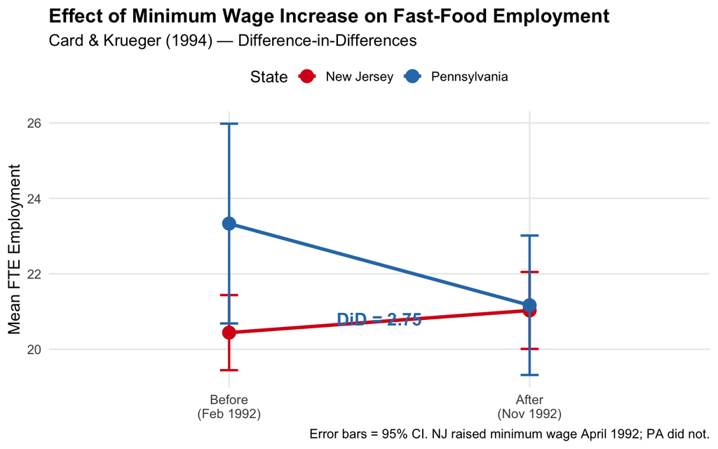

Figure 1: Difference-in-Differences: Average FTE Employment in NJ vs PA

```r
plot_data <- df_long %>%
  group_by(state_name, after) %>%
  summarise(
    mean_fte = mean(fte, na.rm = TRUE),
    se_fte   = sd(fte,   na.rm = TRUE) / sqrt(n()),
    .groups  = "drop"
  ) %>%
  mutate(
    period = if_else(after == 0, "Before\n(Feb 1992)", "After\n(Nov 1992)"),
    period = factor(period, levels = c("Before\n(Feb 1992)", "After\n(Nov 1992)"))
  )

ggplot(plot_data, aes(x = period, y = mean_fte,
                      color = state_name, group = state_name)) +
  geom_line(linewidth = 1.3) +
  geom_point(size = 4.5) +
  geom_errorbar(aes(ymin = mean_fte - 1.96 * se_fte,
                    ymax = mean_fte + 1.96 * se_fte),
                width = 0.06, linewidth = 0.9) +
  annotate("text", x = 1.5, y = 20.8,
           label = paste0("DiD = ", round(did, 2)),
           size = 5, fontface = "bold", color = "#2c7bb6") +
  scale_color_manual(
    values = c("New Jersey" = "#d7191c", "Pennsylvania" = "#2c7bb6"),
    name   = "State"
  ) +
  labs(
    title    = "Effect of Minimum Wage Increase on Fast-Food Employment",
    subtitle = "Card & Krueger (1994) — Difference-in-Differences",
    x        = NULL,
    y        = "Mean FTE Employment",
    caption  = "Error bars = 95% CI. NJ raised minimum wage April 1992; PA did not."
  ) +
  theme_minimal(base_size = 13) +
  theme(
    legend.position  = "top",
    plot.title       = element_text(face = "bold"),
    panel.grid.minor = element_blank()
  )
```

> **图形解读**：如果最低工资减少就业，我们应看到 NJ（红线）在政策后**下降**，而 PA（蓝线）保持稳定。但实际上 NJ 的就业**上升**，PA 下降，DiD = 2.75，说明最低工资对就业**没有负面影响**，甚至略有正效应。

## 7. 结论

本次复现成功验证了 Card & Krueger (1994) 的核心发现：

| 结果 | 论文原文 | 本次复现 |
| --- | --- | --- |
| NJ 调查前 FTE 均值 | 20.44 | 20.44 |
| PA 调查前 FTE 均值 | 23.33 | 23.33 |
| DiD 估计量 | 2.76 | 2.75 |

**为什么 DiD 能得出因果结论？**

传统方法只看 NJ 政策前后的变化，但这会混入宏观经济变化（如经济衰退、季节效应）。DiD 通过**减去 PA 的同期变化**，巧妙地控制了这些共同干扰因素，使我们能将剩余差异归因于最低工资政策本身。

这篇论文的革命性意义在于：它用**自然实验（Natural Experiment）+ 双重差分**方法，在没有随机分配的情况下，得出了近似因果的结论，开创了现代实证经济学的研究范式。

## 参考文献

Card, David, and Alan B. Krueger. 1994. “Minimum Wages and Employment: A Case Study of the Fast-Food Industry in New Jersey and Pennsylvania.” *American Economic Review* 84(4): 772–793.